# GnG EEG Preprocessing Pipeline

Leandro Ledesma

2024-02-17

### Overview

The ONR project is collecting neurophysiological data through EEG recordings. There are three EEG recording sessions. The first is for resting-state EEG, which is obtaining the brain’s electrical activity while participants are not engaging in any activity. Then there is an EEG recording during the Go/No-Go task in VR and finally another EEG recording during the Nback task in VR. We are interested in the data for the GnG EEG recordings. Specifically, we are interested in obtaining event-related potentials (ERPs), which are peaks created in the EEG data after averaging for several trials. In our case, we will be averaging Go and No-Go trials and then obtaining the amplitudes, latencies, and topographical location of these ERPs for analysis. However, before we can begin the analysis, there are several other steps that must be covered first. This document will serve to record what these steps are. Essentially, there is an initial processing state that involves manually adding markers to the EEG data, then we will need to clean the data using EEGLAB plugin functions in MATLAB, then organize the data into final folders so they are ready for analysis, and lastly engage in the analysis portion. This document will cover the first three steps.

Additionally, this document will keep track of file names saved in different directories, which indicate the number of files that have gone through each processing step.

### Universal block code settings

```r
knitr::opts_chunk$set(echo = TRUE)
knitr::opts_chunk$set(message = FALSE)
knitr::opts_chunk$set(comment = NULL)
```

### Load in the data manipulation packages first

```r
library(tidyverse)
library(ggplot2)
library(ggpubr)
library(readxl)
library(lmtest) # bptest() function for homoscedasticity
library(kableExtra)
library(boot)
```

### All GnG EEG data collected so far

```r
# Total number of GnG EEG recordings so far
# Set working directory
setwd("M:/EEG_XDFs/EEG_DATA")

# List all of the files in the first computer
ONR1.EEG.files <- list.files()

# Set working directory
setwd("M:/EEG_XDFs/EEG_DATA2")

# List all of the files in the second computer
ONR2.EEG.files <- list.files()

# Combine all of the EEG files into one vector
ONR.EEG.files.combined <- c(ONR1.EEG.files, ONR2.EEG.files)

# Extract only the GnG files
GnG.EEG.files <- unique(ONR.EEG.files.combined[grepl(pattern = "GnG", x = ONR.EEG.files.combined)])

# Create a data frame that contains the ID's and Days for each of these files
GnG.EEG.df <- data.frame(ID = substr(x = GnG.EEG.files, start = 1, stop =3),
                         Day = substr(x = GnG.EEG.files, start = 5, stop =8),
                         file = GnG.EEG.files)

# Create a variable to detect odd files
GnG.EEG.df <- GnG.EEG.df %>%
  mutate(extra.version = ifelse(grepl(pattern = "_2|_3", file),"Yes", "No"),
         recovered = ifelse(grepl(pattern = "recovered", file), "Yes", "No"))


paste("The total number of GnG EEG recordings so far are:",nrow(GnG.EEG.df))
```

```
[1] "The total number of GnG EEG recordings so far are: 479"
```

```r
paste(length(unique(GnG.EEG.df$ID)),"subjects have at least one GnG EEG recording")
```

```
[1] "180 subjects have at least one GnG EEG recording"
```

```r
GnG.EEG.df$Day %>%
  table()
```

```
.
Day1 Day2 Day3
 186  156  137
```

```r
paste("If the table of days and the number of unique EEG ID's conflict, it is likely because of multiple versions of a GnG file:")
```

```
[1] "If the table of days and the number of unique EEG ID's conflict, it is likely because of multiple versions of a GnG file:"
```

```r
table(GnG.EEG.df$extra.version)
```

```
 No Yes
459  20
```

### Part 1: Adding markers

There are several types of data being recorded during the GnG session. These data are saved as streams and include EEG data, VR specific data such as head and joystick movement, and contains marker information. Essentially, what we need to do is to superimpose the marker data onto the EEG. This is because the markers give us detailed information about each trial presented in the VR GnG. The markers give us information about what stimuli the subject is focused on, very detailed information of the stimulus trial such as the version of the GnG, what type of trial (Go or NoGo), information on the shape, and more. Additionally, there are also markers on the response that the subject initiates during that trial, either hitting the shape or not. Thus, all of this information is invaluable for our EEG analysis since it will tell us which EEG segments should be included in our analysis.

Three scripts using MATLAB were designed for this first step (All are located in the MBAP server).

The first uses MobiLab, something that was downloaded into EEGLAB to basically combine streams of data together and then export them as one file, but as a text file. This has to be done manually- unfortunately, but there might be a way to automate this if I get in contact with Dr. Lindner.

The next line of code takes that txt file with marker data and actually superimposes it onto the EEG data.

Lastly, there is a timing issue involved that needs to be addressed, especially since EEG data is very sensitive to markers being off by a fraction of a second. Thus, another script was created that uses information from a photosensor.

Below we will report all of the GnG EEG data that has markers on them- keep in mind this is a manual process, thus we will expect a fraction of files to be present here from the full number above.

```r
# Set working directory
setwd("M:/EEG_XDFs_Copy_2/0_EEG_DATA_WITH_MARKERS")

# List all of the files
EEG.marker.files <- list.files()[grepl(pattern = ".set", x = list.files())]


# Create a data frame that contains the ID's and Days for each of these files
GnG.EEG.marker.df <- data.frame(ID = substr(x = EEG.marker.files, start = 1, stop =3),
                         Day = substr(x = EEG.marker.files, start = 5, stop =8),
                         file = EEG.marker.files)

# Create a variable to detect odd files
GnG.EEG.marker.df <- GnG.EEG.marker.df %>%
  mutate(extra.version = ifelse(grepl(pattern = "_2|_3", file),"Yes", "No"),
         recovered = ifelse(grepl(pattern = "recovered", file), "Yes", "No"))

paste("The total number of GnG EEG recordings with markers so far are:",nrow(GnG.EEG.marker.df))
```

```
[1] "The total number of GnG EEG recordings with markers so far are: 165"
```

```r
paste(length(unique(GnG.EEG.marker.df$ID)),"subjects have at least one GnG EEG recording")
```

```
[1] "75 subjects have at least one GnG EEG recording"
```

```r
GnG.EEG.marker.df$Day %>%
  table()
```

```
.
Day1 Day2 Day3
  64   57   44
```

```r
paste("If the table of days and the number of unique EEG ID's conflict, it is likely because of multiple versions of a GnG file:")
```

```
[1] "If the table of days and the number of unique EEG ID's conflict, it is likely because of multiple versions of a GnG file:"
```

```r
table(GnG.EEG.marker.df$extra.version)
```

```
 No
165
```

### Part 2: Preprocessing the EEG Data

#### Obtain all of the file na,es

```r
# Get information of the number of files of interest per preprocessing folder
# set working directory
setwd("M:/EEG_XDFs_Copy_2")
global_wd <- setwd("M:/EEG_XDFs_Copy_2")

# Obtain numbers of interest to create the flow chart
all_folder_names <- list.files()

# Create a loop that returns the number files inside each folder
all_folder_file_num_list <- list()

for(ii in 1:length(all_folder_names)) {

  current_wd <- paste(global_wd,"/",all_folder_names[ii],sep="")
  setwd(current_wd)
  getwd()

  files_inside_current_folder <- list.files()
  files_num <- length(files_inside_current_folder)

  current_Tib <- data.frame(Directory = all_folder_names[ii],
                            Files_num = files_num) %>% as_tibble()

  all_folder_file_num_list[[ii]] <- current_Tib

}

preprocessing_flowchart <- do.call(rbind, all_folder_file_num_list)
```

#### Count the file names in each folder

```r
# Start the flow chart generation
# Lets begins with the numeric variables of interest
All_Marker_Data_num <- preprocessing_flowchart %>% filter(Directory == "0_EEG_DATA_WITH_MARKERS") %>% select(Files_num) %>% unlist() %>% as.numeric()/2
Preprocessed_Data_num <- preprocessing_flowchart %>% filter(Directory == "1_Preprocessed EEG data - needs ICA") %>% select(Files_num) %>% unlist() %>% as.numeric()/2
MARA_Ready_Data_num <- preprocessing_flowchart %>% filter(Directory == "2_Preprocessed EEG data - needs MARA and componenet rejection") %>% select(Files_num) %>% unlist() %>% as.numeric()/2
Almost_Cleaned_Data_num <- preprocessing_flowchart %>% filter(Directory == "3_Preprocessed EEG data - needs segmentation rejection") %>% select(Files_num) %>% unlist() %>% as.numeric()/2
Cleaned_Data_num <- preprocessing_flowchart %>% filter(Directory == "4_Fully cleaned EEG data") %>% select(Files_num) %>% unlist() %>% as.numeric()/2

Interpolation_CSV_num <- preprocessing_flowchart %>% filter(Directory == "CSVs_Interpolation number") %>% select(Files_num) %>% unlist() %>% as.numeric()
Component_rej_CSV_num <- preprocessing_flowchart %>% filter(Directory == "CSVs_Component rejected number") %>% select(Files_num) %>% unlist() %>% as.numeric()
Segments_rem_CSV_num <- preprocessing_flowchart %>% filter(Directory == "CSVs_Segments remaining") %>% select(Files_num) %>% unlist() %>% as.numeric()

# Now lets turn them into characters
All_Marker_Data <- paste("(n=",All_Marker_Data_num,")",sep="")
Preprocessed_Data  <- paste("(n=",Preprocessed_Data_num,")",sep="")
MARA_Ready_Data  <- paste("(n=",MARA_Ready_Data_num,")",sep="")
Almost_Cleaned_Data  <- paste("(n=",Almost_Cleaned_Data_num,")",sep="")
Cleaned_Data <- paste("(n=",Cleaned_Data_num,")",sep="")
Interpolation_CSV <- paste("(n=",Interpolation_CSV_num,")",sep="")
Component_rej_CSV <- paste("(n=",Component_rej_CSV_num,")",sep="")
Segments_rem_CSV <- paste("(n=",Segments_rem_CSV_num,")",sep="")
```

#### Visualize the number of files for each preprocessing step

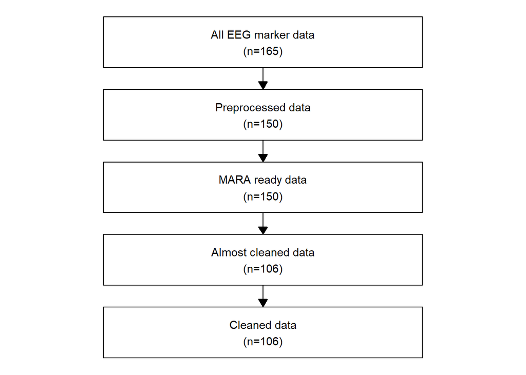

```r
# Add labels manually
labels <- c(paste("All EEG marker data",All_Marker_Data, sep="\n"),
            paste("Preprocessed data",Preprocessed_Data, sep="\n"),
            paste("MARA ready data",MARA_Ready_Data, sep="\n"),
            paste("Almost cleaned data",Almost_Cleaned_Data, sep="\n"),
            paste("Cleaned data",Cleaned_Data, sep="\n"))


# Create a data with box labels
data <- data.frame(box = paste("box",1:5))


# Create a data frame with coordinates for the boxes
coords <- data.frame(x = c(1, 1, 1, 1, 1),
                      y = c(10, 9, 8, 7, 6))

# Design min and max for x and y coordinates and include labels from above
coords <- coords %>%
  mutate(xmin = x - 0.20,
         xmax = x + 0.20,
         ymin = y - 0.35,
         ymax = y + 0.35) %>%
  mutate(labels = labels)

# WHat does our data look like so far
cbind.data <- cbind(data, coords)

# Create a separate data frame telling the arrows where to start and end
plot_edges <- data %>%
  rename(from = box) %>%
  mutate(to = paste("box",2:6),
         id = row_number()) %>%
  pivot_longer(cols = c("from", "to"),
               names_to = "Direction",
               values_to = "box") %>%
  left_join(cbind.data, by ="box") %>%
  select(-c(y, xmin, xmax, labels)) %>%
  mutate(y = ifelse(Direction == "from",ymin, ymax)) %>%
  select(-c(ymin, ymax)) %>%
  filter(complete.cases(.))

# Plotting the graph- one step at a time
# Part 1: Creating the Boxes
plot1 <- ggplot() +
  geom_rect(data = coords,
            mapping = aes(xmin = xmin, ymin = ymin,
                          xmax = xmax, ymax = ymax,
                          fill = "white", color = "black" ),
            alpha = 0.5)

# Part 2: Making the boxes and background pretty
plot1 <- plot1 +
  scale_fill_manual(values = "white") +
  scale_color_manual(values = "black") +
  theme_void() +
  theme(legend.position = "none") +
  xlim(.7,1.3)

# Part 3: Adding the labels we created (file names + counts)
plot1 <- plot1 +
  geom_text(data = coords,
            mapping = aes(x = x, y = y, label = labels))

# Part 4: Adding the arrows to the boxes
plot1 <- plot1 +
  geom_path(data = plot_edges,
            mapping = aes(x = x, y = y, group = id),
            arrow = arrow(length = unit(0.3, "cm"), type = "closed"))

# Print the plot
plot1
```